# NCSC Referee Report

This report was created using data scraped of [Oregon Soccer Central](https://www.oregonsoccercentral.com) as well as the registered referees spreadsheets that are distributed by the [Oregon Referee Committe](https://www.oregonreferee.com).

## Summary Information

Right now there are **207** referees listed in our organization.

Of those, **72** have 2022 registrations completed. Of currently registered refs, **17** worked games in 2021.

Of the 10 refs who have worked at least 4 games since 2021, 4 identify as female.

Here is a breakdown of the crew officiating games since 2017. Note there were no games in 2020 because of the pandemic. Also note that this only includes referees who were registered in 2019 or later.

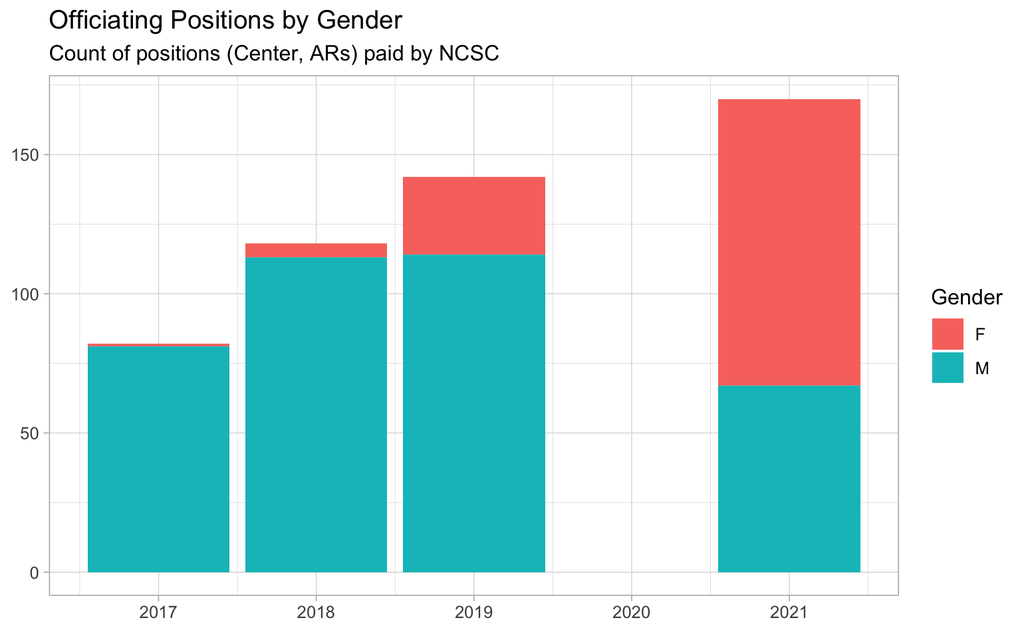

## Data Doctor

I ran these scripts to update data on [http://www.oregonsoccercentral.com]. The changes have already been applied so there shouldn’t be any more adjustments needed.

For refs that have actually worked games for us, the `FirstYear` and `LastYear` fields will reflect games actually worked. If our manually entered `InitialYear` and `CurrentYear` don’t align with actual games worked, we can fix that.

Refs needing adjustment: 0

Some refs had their Current Year entered but not the initial year. Maybe when setting up the ref initially, we just didn’t bother setting this field. For these situations, I’ll assume the Initial Year is the same as the Current Year.

Refs needing adjustment: 0

Some refs did not get their ranks set. These will show up as NA or 0. Let’s default the Center rank to 1 (7v7) and AR to 2 (9v9)

Refs needing adjustment: 0

## Refs by Experience

Here is the list of the top 50 refs by number of games.

| Name | Age | Total Games | 11v11 | 9v9 | 7v7 | Reg 22? | Most Recent Year | Last Logged In |
| --- | --- | --- | --- | --- | --- | --- | --- | --- |
| John Mathews | 51 | 60 | 34 | 22 | 4 | FALSE | 2019 | 2019-09-28 |
| Tim Hueer | 39 | 41 | 21 | 15 | 5 | TRUE | 2019 | 2022-02-27 |
| Carter Lancaster | 17 | 41 | 13 | 18 | 10 | FALSE | 2019 | 2022-02-14 |
| Christopher Taylor | 23 | 41 | 9 | 19 | 13 | FALSE | 2016 | 2019-09-30 |
| Elyse Pauken | 16 | 35 | 12 | 12 | 11 | TRUE | 2021 | 2021-11-29 |
| Victor Prudhomme | 52 | 35 | 7 | 22 | 6 | FALSE | 2021 | 2021-10-31 |
| Norah Perkins | 17 | 33 | 13 | 7 | 13 | FALSE | 2021 | 2021-11-10 |
| Lydia Altman | 16 | 25 | 12 | 13 | 0 | TRUE | 2021 | 2021-10-30 |
| Daniel Wilson | 20 | 20 | 3 | 14 | 3 | FALSE | 2017 | 2020-03-09 |
| Felix Kayser | 16 | 19 | 8 | 3 | 8 | TRUE | 2021 | 2022-03-13 |
| Jonathan Wilson | 23 | 18 | 7 | 6 | 5 | FALSE | 2018 | 2020-03-09 |
| Elijah Wright | 18 | 16 | 3 | 4 | 9 | FALSE | 2019 | 2019-11-03 |
| Grace Prudhomme | 15 | 15 | 2 | 13 | 0 | TRUE | 2021 | 2022-03-03 |
| Bill Kayser | 55 | 13 | 8 | 3 | 2 | TRUE | 2021 | 2022-03-15 |
| John Miller | 73 | 12 | 8 | 4 | 0 | FALSE | 2019 | 2022-01-15 |
| Christian Olsen | 18 | 12 | 5 | 6 | 1 | FALSE | 2019 | 2021-06-19 |
| Alex Stoeff | 22 | 12 | 1 | 5 | 6 | FALSE | 2013 | 2021-03-09 |
| Roland Boehrer | 54 | 10 | 2 | 5 | 3 | FALSE | 2018 | 2022-03-08 |
| Elliot Orr | 16 | 10 | 0 | 3 | 7 | FALSE | 2018 | 2022-02-04 |
| Elijah Perry | 14 | 9 | 1 | 0 | 8 | FALSE | 2021 | 2021-12-05 |
| Noah Ross | 17 | 9 | 2 | 7 | 0 | FALSE | 2019 | 2021-06-07 |
| Ole Kittleson | 18 | 8 | 1 | 5 | 2 | FALSE | 2019 | 2019-11-06 |
| Sam Portis | 16 | 8 | 0 | 0 | 8 | TRUE | 2021 | 2022-03-11 |
| Oswaldo Espadas | 15 | 7 | 0 | 0 | 7 | TRUE | 2021 | 2022-03-15 |
| Robert Jimenez-sutton | 28 | 7 | 7 | 0 | 0 | FALSE | 2018 | 2022-03-11 |
| Josepher Juarez-cruz | 18 | 7 | 1 | 6 | 0 | FALSE | 2018 | 2021-12-25 |
| Jeffrey Rine | 57 | 7 | 4 | 1 | 2 | TRUE | 2021 | 2022-03-14 |
| Cole Smithpeter | 18 | 7 | 1 | 2 | 4 | FALSE | 2019 | 2021-04-30 |
| Tristan Hansen | 18 | 6 | 0 | 5 | 1 | FALSE | 2019 | 2020-01-24 |
| Gabe Hawkins | 16 | 6 | 0 | 6 | 0 | TRUE | 2018 | 2022-03-12 |
| Andre Klingler | 18 | 6 | 6 | 0 | 0 | FALSE | 2017 | 2021-10-27 |
| Brandt Maiden | 18 | 6 | 4 | 1 | 1 | FALSE | 2019 | 2022-01-25 |
| Carter Mitchelldyer | 14 | 6 | 2 | 4 | 0 | FALSE | 2021 | 2021-10-10 |
| Adin Williams | 21 | 6 | 2 | 4 | 0 | FALSE | 2018 | 2021-06-30 |
| Lucas Nelson | 20 | 4 | 4 | 0 | 0 | TRUE | 2018 | 2019-09-24 |
| Isley Tomlinson | 16 | 4 | 0 | 4 | 0 | FALSE | 2019 | 2019-10-30 |
| Bella Torrez | 14 | 4 | 0 | 4 | 0 | TRUE | 2021 | 2021-10-10 |
| Adrian Carlson | 15 | 3 | 2 | 1 | 0 | TRUE | 2021 | 2022-03-13 |
| Mason Cruz | 17 | 3 | 0 | 3 | 0 | FALSE | 2018 | 2019-05-03 |
| Efren Herrera | 53 | 3 | 2 | 1 | 0 | TRUE | 2019 | 2022-03-15 |
| Caleb Hillard | 14 | 3 | 0 | 3 | 0 | FALSE | 2019 | 2021-08-23 |
| Minh Hoang | 32 | 3 | 3 | 0 | 0 | FALSE | 2017 | 2020-01-12 |
| Liam Madison | 16 | 3 | 3 | 0 | 0 | FALSE | 2021 | 2022-02-28 |
| Elsie Marineau | 17 | 3 | 1 | 2 | 0 | FALSE | 2018 | 2021-08-05 |
| Gavin Redpath | 18 | 3 | 0 | 0 | 3 | FALSE | 2018 | 2021-04-12 |
| Francesca Young | 15 | 3 | 2 | 0 | 1 | TRUE | 2021 | 2021-12-22 |
| Tyler Bennett | 20 | 2 | 0 | 0 | 2 | FALSE | 2017 | 2020-12-19 |
| Kyra Boag | 15 | 2 | 0 | 0 | 2 | TRUE | 2021 | 2022-03-13 |
| Lilly Boehrer | 17 | 2 | 0 | 2 | 0 | FALSE | 2018 | 2020-02-16 |
| Zach Brehm | 21 | 2 | 2 | 0 | 0 | TRUE | 2015 | 2022-03-14 |

## Distribution Lists

Send out email in groups:

There are 62 referees to communicate with:

- Currently Registered Grassroots Refs (details on club, dates, etc) - **72**
  - Recent refs who are likely to come back for Spring - **6**
  - Brand new certified refs - **16**
  - Remaining refs that have done some games in 20-21 at least - **14**.
- Out of date Grassroots registrations (encourage to re-register) - **58**
  - Recent refs who are likely to come back - **4**
  - Refs that are recently certified but have not updated their registration and still have not done games with us - **5**
  - Refs that have done at least one game in 20-21 but are not already included above - **17**

There are 145 refs who will just be asked if they want to be removed.

### Current 2022 Referees

These are all refs who have up to date registration and ready to play this spring.

#### Up-to-date Active Refs

These are refs who did at least 4 games in 2021 and have updated their registration. They are the most likely candidates for taking games this year. There are 6.

| Name | Gender | Age | City | Reg. Since | Games to Date | Signup Notes |
| --- | --- | --- | --- | --- | --- | --- |
| Grace Prudhomme | F | 15 | Milwaukie | 2021 | 15 |  |
| Oswaldo Espadas | M | 15 | Milwaukie | 2021 | 7 | I've played soccer since a really young age, I have been a referee since April 2021, since then I've had games for almost every weekend. I have reffed as a center in U19 and below and I have been and … |
| Sam Portis | M | 16 | Clackamas | 2021 | 8 | I just got my badge today so I am getting signed up. I mostly want to ref 7v7 games for smaller kids. I might move up in the future, though I dont know yet. I have been playing soccer since I was 7, I… |
| Lydia Altman | F | 16 | Milwaukie | 2019 | 25 |  |
| Elyse Pauken | F | 16 | Milwaukie | 2018 | 35 |  |
| Felix Kayser | M | 16 | Portland | 2018 | 19 |  |

```
"Lydia Altman"<altmanlydia@gmail.com>, "Oswaldo Espadas"<osocuentadejuegos@gmail.com>, "Oswaldo Espadas"<oswaldo.espadas@gmail.com>, "Felix Kayser"<felix@kayser.org>, "Elyse Pauken"<empauken@gmail.com>, "Sam Portis"<samportis246@gmail.com>, "Grace Prudhomme"<gracieprudhomme@gmail.com>, "Grace Prudho…
```

#### Brand New Certified Refs

These are refs who got certified in 2021 but have not done games for us yet.

| Name | Gender | Age | City | Reg. Since | Games to Date | Signup Notes |
| --- | --- | --- | --- | --- | --- | --- |
| Oscar Johnson | M | 13 | Milwaukie | 2022 | 0 | Been playing soccer for almost 10 years. |
| Brooke Wesener | F | 13 | Happy valley | 2021 | 0 |  |
| Sergio Trivino veloza | M | 13 | Beaverton | 2021 | 0 |  |
| Isabella Arms | F | 14 | Damascus | 2021 | 0 | I am brand new to being a referee and am so excited to get started. |
| Javier Galindo-schmith | M | 14 | Damascus | 2021 | 0 |  |
| Lanie Van vleet | F | 14 | Portland | 2021 | 0 |  |
| Malia Savage | F | 14 | Clackamas | 2021 | 0 |  |
| Rylan De souza | M | 14 | Happy valley | 2021 | 0 |  |
| Sasha Sychov-hanoosh | M | 14 | Portland | 2021 | 0 |  |
| Addison Huss | F | 15 | Portland | 2021 | 0 |  |
| Josh Huss | M | 15 | Portland | 2021 | 0 |  |
| Katherine Shaver | F | 15 | Portland | 2021 | 0 | for the training I took the grassroot training and have my grassroot license. I never have been a ref but I do play soccer. |
| Nolan Smith | M | 15 | West linn | 2021 | 0 | This is my first time reffing i have been playing the sport for 10 years i am 14 now as we speak this will be my second job and would love to give it a try because i love the sport soccer. |
| Mali Kleiv | F | 16 | Portland | 2021 | 0 |  |
| Amanda Nguyen | F | 23 | Happy valley | 2021 | 0 | I am a former collegiate player and now starting to referee |
| Dave Smart | M | 53 | Tigard | 2021 | 0 | I obtained my USSF Grassroots Referee license in 2021, but I've played soccer for 45 years and still play on three teams today. I also coached youth soccer for 20 years, most recently in 2018 at the h… |

```
"Isabella Arms"<bellaarms1622@gmail.com>, "Isabella Arms"<juliaarms@gmail.com>, "Rylan De souza"<r3_desouza@msn.com>, "Javier Galindo-schmith"<javiergalindoschmith@gmail.com>, "Addison Huss"<addyhuss7@gmail.com>, "Josh Huss"<joshhuss14@gmail.com>, "Oscar Johnson"<oscarjohnson1103@gmail.com>, "Oscar …
```

#### Other Likely Candidates

| Name | Gender | Age | City | Reg. Since | Games to Date | Signup Notes |
| --- | --- | --- | --- | --- | --- | --- |
| Tim Hueer | M | 39 | Portland | 2016 | 41 |  |
| Bill Kayser | M | 55 | Portland | 2018 | 13 |  |
| Jeffrey Rine | M | 57 | Oregon city | 2018 | 7 |  |
| Bella Torrez | F | 14 | Milwaukie | 2021 | 4 | Would like to do AR until super comfortable. |
| Adrian Carlson | M | 15 | Portland | 2021 | 3 |  |
| Francesca Young | F | 15 | Milwaukie | 2019 | 3 |  |
| Efren Herrera | M | 53 | Clackamas | 2013 | 3 | I've been Center and Assisting referee for about 20+ years. When I started refereeing, I was in High School. I've played soccer my entire life, been coach for youth and recreational teams in Mexico an… |
| Serafina Preciso | F | 14 | Portland | 2021 | 2 |  |
| Kyra Boag | F | 15 | Happy valley | 2021 | 2 |  |
| Gerard Mangan | M | 68 | Portland | 2022 | 2 |  |
| Evan Hoobler | M | 14 | Wilsonville | 2021 | 1 |  |
| Landon Rasmussen | M | 15 | Clackamas | 2021 | 1 |  |
| Marisa Hurlbert | F | 30 | Portland | 2021 | 1 | As a new ref, I am most comfortable working as an AR. I prefer to commute to games in SE Portland or Clackamas/Happy Valley area. But open to going to Delta Park or other games similar distance for 3-… |
| Bruce Fries | M | 42 | Oregon City | 2021 | 1 |  |

```
"Kyra Boag"<kyraboag@gmail.com>, "Kyra Boag"<theboags@gmail.com>, "Adrian Carlson"<adriancarlson90@gmail.com>, "Bruce Fries"<bruce.fries@yahoo.com>, "Efren Herrera"<fairplay1968@gmail.com>, "Efren Herrera"<herrera_efren@yahoo.com>, "Evan Hoobler"<niskit07@gmail.com>, "Evan Hoobler"<megiej@yahoo.com>…
```

### Refs with Out-of-date Registration

These refs have not update their registration at this time but still have potential to do games in Spring.

#### Active Refs

| Name | Gender | Age | City | Reg. Since | Games to Date | Signup Notes |
| --- | --- | --- | --- | --- | --- | --- |
| Victor Prudhomme | M | 52 | Portland | 2016 | 35 |  |
| Norah Perkins | F | 17 | Milwaukie | 2019 | 33 |  |
| Elijah Perry | M | 14 | Milwaukie | 2021 | 9 |  |
| Carter Mitchelldyer | M | 14 | Milwaukie | 2021 | 6 |  |

```
"Carter Mitchelldyer"<cartermitchelldyer@gmail.com>, "Norah Perkins"<norahperk@gmail.com>, "Norah Perkins"<crawfordmg@yahoo.com>, "Elijah Perry"<arbiteredp@gmail.com>, "Elijah Perry"<kd4679@msn.com>, "Victor Prudhomme"<vaprudhomme@comcast.net>
```

#### New Refs

| Name | Gender | Age | City | Reg. Since | Games to Date | Signup Notes |
| --- | --- | --- | --- | --- | --- | --- |
| Theo Tzantarmas | M | 17 | Tualatin | 2021 | 0 |  |
| Lila Wagner | F | 16 | Portland | 2021 | 0 |  |
| Benjamin Vice | M | 15 | Portland | 2021 | 0 | Im excited to start my Referee career. |
| Hector Perez | M | 14 | Portland | 2021 | 0 |  |
| Hudson Akines | M | 14 | Gresham | 2021 | 0 |  |

```
"Hudson Akines"<hrakines12@gmail.com>, "Hudson Akines"<wtakines@comcast.net>, "Hector Perez"<Hectorperez42@icloud.com>, "Hector Perez"<Tabsauce@yahoo.com>, "Theo Tzantarmas"<tytzantarmas@gmail.com>, "Theo Tzantarmas"<pilatesofportland@gmail.com>, "Benjamin Vice"<koopervice@gmail.com>, "Benjamin Vice…
```

#### Inactive Refs

These refs are not currently registered but have done some games at least since 2019 and are not in one of the groups above.

| Name | Gender | Age | City | Reg. Since | Games to Date | Signup Notes |
| --- | --- | --- | --- | --- | --- | --- |
| Carter Lancaster | M | 17 | Oregon city | 2018 | 41 | I''ve played soccer since 2011. |
| John Miller | M | 73 | Portland | 2002 | 12 | I am USSF certified referee for the 2020 season and refereed men's adult centers up to four or five per day for GPSD for several of the last years as well as womens centers for NUWS solo and MISOA hig… |
| Christian Olsen | M | 18 | Damascus | 2017 | 12 |  |
| Noah Ross | M | 17 | Portland | 2018 | 9 |  |
| Brandt Maiden | M | 18 | Happy Valley | 2019 | 6 |  |
| Liam Madison | M | 16 | Lake Oswego | 2019 | 3 |  |
| Caleb Hillard | M | 14 | Milwaukie | 2019 | 3 |  |
| Igor Chevtchenko | M | 62 | Portland | 2012 | 2 | Total of 136 games in 2019. FC PDX College Showcase 2016, United Winter Showcase 2016, TTPL spring league 2019, Timbers Friendship Cup 2019, President's Cup 2019, Bend Cup 2019, Mt.Hood Challenge 2019… |
| Logan Warner | M | 20 | Clackamas | 2016 | 2 | I am sixteen years old and have been playing soccer since I was four. I currently play for the A team on the Crossfires 01 boys team. My brother plays for EastSide and my dad coaches. 2015 was my firs… |
| Ashton Maiden | M | 18 | Happy Valley | 2019 | 2 |  |
| Reuben De souza | M | 17 | Happy Valley | 2019 | 2 |  |
| Alyssa Palmer | F | 15 | Oregon city | 2021 | 2 |  |
| Liko Edelen hare | M | 14 | Portland | 2021 | 2 | I have been playing club soccer for the past five years and have played rec soccer since I was three. I also play on my school team. I attend Catlin Gabel School. I am eager to get started refereeing.… |
| Colleen Johnston | F | 46 | Portland | 2014 | 1 | I have been refereeing since 2014. Additionally, I played DII soccer in college. I have coached for several years - four being the assistant coach at Willamette University. I have a USSF C coaching li… |
| Daniel Snelgrow jr. | M | 31 | Washougal | 2007 | 1 | I have officiated on both military bases and for a few smaller side tournaments. Most of have been kids under the age of 16. I have also ref''d college intramurals. |
| Bria Martin | F | 15 | Gladstone | 2019 | 1 |  |
| Hailee Schoenborn | F | 15 | Clackamas | 2021 | 1 |  |

```
"Igor Chevtchenko"<1994tango@gmail.com>, "Reuben De souza"<r2d2.az11@gmail.com>, "Liko Edelen hare"<edelenharel@catlin.edu>, "Liko Edelen hare"<vhare@psmfc.org>, "Caleb Hillard"<mindydhillard@hotmail.com>, "Caleb Hillard"<hillardc@nclack.org>, "Colleen Johnston"<soccer_colleen@yahoo.com>, "Carter La…
```

### Completely Inactive

These are all of the refs in our organization who don’t fit one of the categories above. Generally they probably signed up years ago and never bothered to take games. I’ll send an email out just seeing if they want to stay in the org.

```
"Sam Adams"<sam_adams04@icloud.com>, "Sam Adams"<mara.adams@me.com>, "Matthew Aizawa"<mattzawa2003@gmail.com>, "Matthew Aizawa"<yukoai16@gmail.com>, "Magdalena Alonzo"<freedom15mags@gmail.com>, "Ramon Aragon"<aragon.ramon@gmail.com>, "Ramon manuel Aragon"<ramonmaragon@gmail.com>, "Ramon manuel Arago…
```